# Question

Una bibliotecaria, Adriana, registró el número de libros prestados por cada estudiante este semestre. Los datos recopilados para 10 estudiantes se muestran en la siguiente tabla:

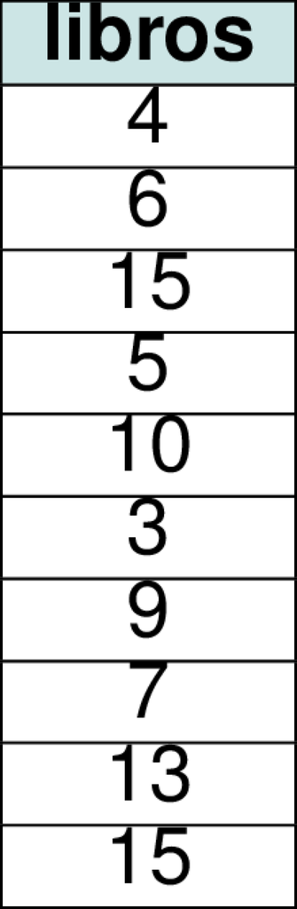

Martín, un compañero de clase, analizó estos datos y afirmó: *“La mediana de este conjunto de datos es 6.5”*.

Sin embargo, Adriana sospecha que Martín cometió un error conceptual.

**Parte 1.** ¿Cuál error conceptual cometió Martín al calcular la mediana?

##ANSWER1##

**Parte 2.** Calcule la media aritmética correcta de los datos (redondee a dos decimales si es necesario). *Escriba el número decimal con punto; por ejemplo: 73.25*

##ANSWER2##

**Parte 3.** Calcule la mediana correcta de los datos. *Si el resultado es decimal, use punto; por ejemplo: 68.5*

##ANSWER3##

**Parte 4.** Determine si la siguiente afirmación es verdadera o falsa: *“Si todos los datos de un conjunto son iguales, entonces la media, la mediana y la moda coinciden.”*

##ANSWER4##

## Answerlist

- Para un número par de datos, tomó solo uno de los dos valores centrales
- No ordenó los datos antes de buscar la mediana
- Confundió la mediana con la media aritmética
- Confundió la moda con el valor máximo del conjunto
- Verdadero
- Falso

# Solution

### Análisis del Error (Parte 1)

Martín afirmó que la mediana es **6.5**, cuando la mediana correcta es **8**.

**Error identificado:** El estudiante tomó el valor que ocupa la posición central en la lista TAL COMO SE PRESENTA (sin ordenarla). La mediana requiere que los datos estén ordenados de menor a mayor antes de identificar el valor central.

**Código de error:** EST-MTC-03

**Causa raíz:** Omite el paso previo de ordenamiento ascendente

Es posible que los estudiantes que eligen otras opciones no distingan claramente entre las tres medidas de tendencia central (media, mediana y moda) o confundan los procedimientos de cálculo de cada una.

### Procedimiento Correcto (Parte 2 y 3)

**Cálculo de la media aritmética:**

**Paso 1:** Sumar todos los datos.

$$\text{Suma} = 3 + 4 + 5 + 6 + 7 + 9 + 10
+ 13 + 15 + 15 = 87$$

**Paso 2:** Dividir entre el número de datos.

$$\text{Media} = \frac{87}{10} =
8.7$$

**Cálculo de la mediana:**

**Paso 1:** Ordenar los datos de menor a mayor.

$$3,\; 4,\; 5,\; 6,\; 7,\; 9,\; 10,\;
13,\; 15,\; 15$$

**Paso 2:** Como hay 10 datos (número **par**), la mediana es el promedio de los dos valores centrales (posiciones 5 y 6).

$$\text{Mediana} = \frac{7 + 9}{2} =
8$$

**Moda:** El valor 15 aparece 2 veces (la mayor frecuencia), por lo tanto $\text{Moda} = 15$.

### Propiedades de las Medidas de Tendencia Central (Parte 4)

Si todos los datos de un conjunto son iguales, entonces la media, la mediana y la moda coinciden. $\to$ **Verdadero**

Esta afirmación es **verdadera**. La justificación se basa en las propiedades matemáticas de las medidas de tendencia central.

### Caso Específico

En este conjunto de datos: Media = 8.7, Mediana = 8, Moda = 15. Las tres medidas son diferentes, lo cual es frecuente cuando la distribución de los datos no es simétrica.

### Reflexión Metacognitiva

Analizar por qué una respuesta es incorrecta es tan valioso como saber calcular la correcta. Esto fortalece la comprensión profunda del concepto.

### Estrategia para Evitar el Error

1. **Siempre ordenar** los datos de menor a mayor antes de calcular la mediana.
2. **Verificar** si $n$ es par o impar para aplicar la regla correspondiente.
3. **Distinguir** claramente entre media (promedio), mediana (valor central) y moda (más frecuente).
4. **Comprobar** que la respuesta tenga sentido: la media y la mediana deben estar entre el valor mínimo y el máximo.

## Answerlist

- Incorrecto. Este no es el error que explica la respuesta del compañero.
- Correcto. Este es el error que cometió el compañero.
- Incorrecto. Este no es el error que explica la respuesta del compañero.
- Incorrecto. Este no es el error que explica la respuesta del compañero.
- La media correcta es $8.7$ libros.
- La mediana correcta es $8$ libros.
- Correcto. La afirmación es verdadera.
- Incorrecto.

# Meta-information

exname: media_mediana_moda_metacognitivo_interpretacion_n2_cloze_v1 extype: cloze exclozetype: schoice|num|num|schoice exsolution: 0100|8.7|8|10 exshuffle: TRUE extol: 0|0.01|0.01|0 exsection: Estadistica-Probabilidad|Pensamiento-Aleatorio|Medidas-Tendencia-Central exextra[Type]: CLOZE exextra[Program]: R exextra[Language]: es exextra[Competencia]: Interpretacion exextra[Componente]: Aleatorio exextra[Afirmacion]: Interpreta y diferencia las medidas de tendencia central (media, mediana y moda) identificando errores conceptuales en su calculo exextra[Evidencia]: Identifica errores en el calculo de la mediana y aplica correctamente los procedimientos para media, mediana y moda exextra[Nivel]: 2 exextra[Contexto]: Escolar exextra[DOK]: 3 exextra[Bloom]: Analizar exextra[SOLO]: Relacional exextra[TipoMetacognicion]: analisis_error